# Discussion 2.1: Preliminary Analysis - California Housing Permits

Applied Time Series Analysis (ADS 506) - Module 2

Jordan Blackman

2026-10-28

# Executive Summary

This document conducts the preliminary time series analysis for **Discussion 2.1: Perform a Preliminary Analysis of a Proposed Dataset**.

Mirroring the methodology demonstrated by **Professor Dave Hurst** in the Module 2 Presentation and Lab 2.1 notes, this analysis focuses on **California monthly new private housing units authorized by building permits (`CABPPRIV`)** from 1988 to the present. We evaluate: 1. **Time Series Linear Models (`TSLM`)** with monthly seasonal dummy factors, a secular deterministic trend, and a post-2008 Great Financial Crisis (GFC) structural break indicator. 2. **Auto-selected Exponential Smoothing State Space Models (`ETS`)**. 3. **Out-of-sample forecast accuracy** on a holdout test partition (2024–2026).

# 1. Environment & Data Ingestion

```r
library(tidyverse)
library(fpp3)
library(readr)
```

We load the monthly California building permits series sourced from the **U.S. Census Bureau and HUD via FRED (`CABPPRIV`)**.

```r
# Locate and read data
data_path <- "/Users/Jordan/Desktop/ADS 506/data/CABPPRIV.csv"

# Fallback download from FRED if not cached locally
if (!file.exists(data_path)) {
  dir.create(dirname(data_path), recursive = TRUE, showWarnings = FALSE)
  download.file("https://fred.stlouisfed.org/graph/fredgraph.csv?id=CABPPRIV", data_path, quiet = TRUE)
}

ca_raw <- read_csv(data_path, show_col_types = FALSE)
names(ca_raw) <- c("date", "permits")

# Construct monthly tsibble
ca_ts <- ca_raw |>
  mutate(Month = yearmonth(date)) |>
  select(Month, permits) |>
  as_tsibble(index = Month)

# Summary inspection
glimpse(ca_ts)
```

```
## Rows: 464
## Columns: 2
## $ Month   <mth> 1988 Jan, 1988 Feb, 1988 Mar, 1988 Apr, 1988 May, 1988 Jun, 19…
## $ permits <dbl> 13840, 15857, 21863, 23003, 21325, 25993, 19697, 24146, 18614,…
```

# 2. Exploratory Analysis & STL Decomposition

Following Module 1 and Lab 2.1 practices, we inspect the series components: **Level, Trend, 12-Month Annual Seasonality (**$s=12$), and Remainder Noise.

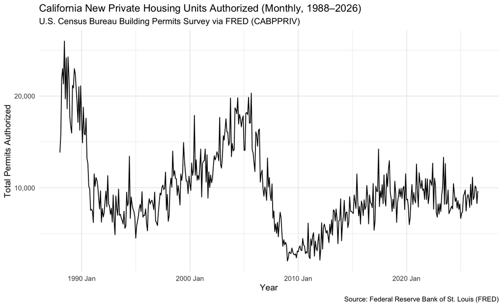

```r
# Time plot of full historical series
ca_ts |>
  autoplot(permits) +
  scale_y_continuous(labels = scales::comma) +
  labs(
    title = "California New Private Housing Units Authorized (Monthly, 1988–2026)",
    subtitle = "U.S. Census Bureau Building Permits Survey via FRED (CABPPRIV)",
    caption = "Source: Federal Reserve Bank of St. Louis (FRED)",
    y = "Total Permits Authorized",
    x = "Year"
  ) +
  theme_minimal()
```

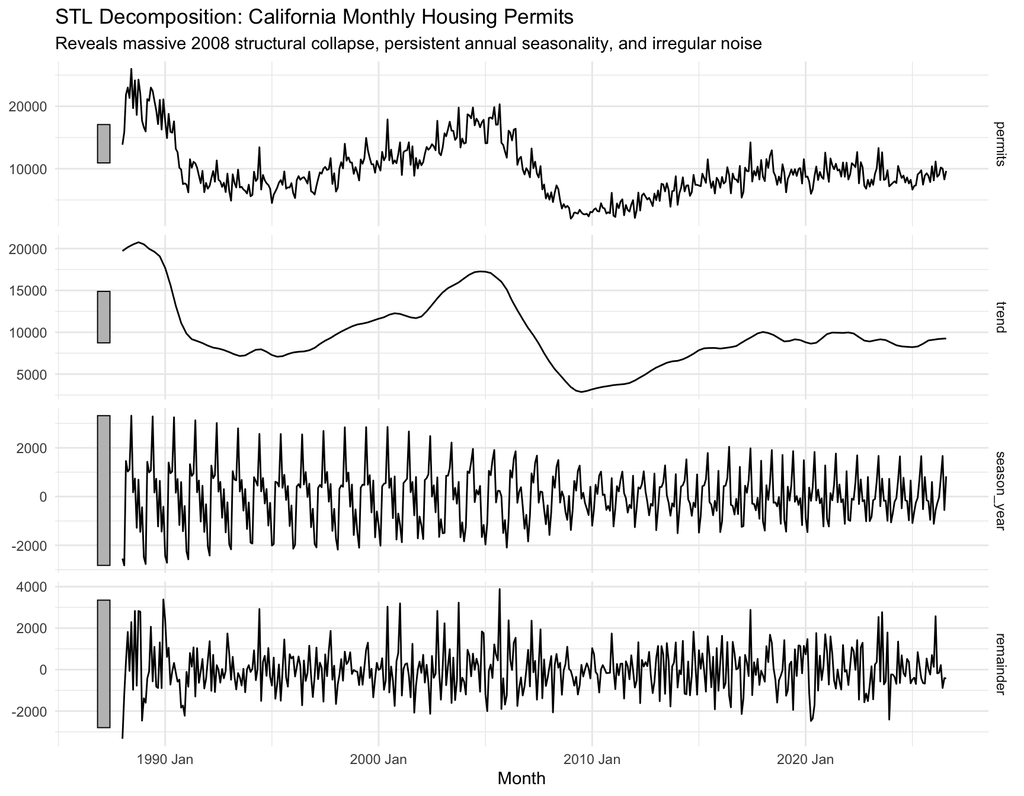

```r
# STL Decomposition
ca_stl <- ca_ts |>
  model(stl = STL(permits)) |>
  components()

autoplot(ca_stl) +
  labs(
    title = "STL Decomposition: California Monthly Housing Permits",
    subtitle = "Reveals massive 2008 structural collapse, persistent annual seasonality, and irregular noise"
  ) +
  theme_minimal()
```

# 3. Feature Engineering & Temporal Train/Test Partitioning

Mirroring Professor Hurst’s approach in Lab 2.1 (where he engineered `month` factors and a holiday indicator `is_July4` to prevent degrees-of-freedom explosion): * **`month`**: 11 calendar month dummy factors (with January as reference). * **`is_post_2008`**: Step-intervention indicator for the post-October 2008 subprime crisis structural break, addressing peer feedback from Discussion 1.1 regarding model overshooting. * **Holdout Partition**: * **Training Set (`ca_trn`)**: January 1988 through December 2023 ($N = 432$ months). * **Test Set (`ca_tst`)**: January 2024 through August 2026 ($N = 32$ months $\approx 2.5$ years).

```r
val_cutoff <- yearmonth("2024 Jan")

ca_prep <- ca_ts |>
  mutate(
    month = factor(month.abb[month(Month)], levels = month.abb),
    is_post_2008 = Month >= yearmonth("2008 Oct")
  )

ca_trn <- ca_prep |> filter(Month < val_cutoff)
ca_tst <- ca_prep |> filter(Month >= val_cutoff)

cat("Training periods:", nrow(ca_trn), "months\n")
```

```
## Training periods: 432 months
```

```r
cat("Holdout test periods:", nrow(ca_tst), "months\n")
```

```
## Holdout test periods: 32 months
```

# 4. Model Estimation: Candidate TSLM & Automated ETS

We estimate four competing specifications in a unified `fable::model()` pipeline: 1. **`tslm_basic`**: Baseline linear model with linear trend and generic annual seasonality (`trend() + season()`). 2. **`tslm_month`**: Parsimonious monthly dummy variables (`trend() + month`). 3. **`tslm_regime`**: Monthly dummies + trend + post-2008 structural break indicator (`trend() + month + is_post_2008`). 4. **`ets_auto`**: Auto-selected Exponential Smoothing state space model.

```r
ca_fit <- ca_trn |>
  model(
    tslm_basic  = TSLM(permits ~ trend() + season()),
    tslm_month  = TSLM(permits ~ trend() + month),
    tslm_regime = TSLM(permits ~ trend() + month + is_post_2008),
    ets_auto    = ETS(permits)
  )
```

# 5. Model Parameters & Regression Diagnostic Output

Below is the detailed regression output for the best-performing linear model (`tslm_regime`), formatted identically to Professor Hurst’s benchmark exemplar:

```r
report(ca_fit |> select(tslm_regime))
```

```
## Series: permits
## Model: TSLM
##
## Residuals:
##     Min      1Q  Median      3Q     Max
## -9448.9 -2847.1  -436.6  2066.2 13320.4
##
## Coefficients:
##                   Estimate Std. Error t value Pr(>|t|)
## (Intercept)       9188.329    747.576  12.291  < 2e-16 ***
## trend()              8.215      2.878   2.854  0.00453 **
## monthFeb            88.591    908.939   0.097  0.92240
## monthMar          2258.959    908.952   2.485  0.01334 *
## monthApr          2049.549    908.975   2.255  0.02466 *
## monthMay          2308.723    909.007   2.540  0.01145 *
## monthJun          3727.897    909.048   4.101 4.95e-05 ***
## monthJul          1457.904    909.098   1.604  0.10954
## monthAug          1855.245    909.158   2.041  0.04192 *
## monthSep           867.557    909.226   0.954  0.34055
## monthOct          1683.137    909.035   1.852  0.06479 .
## monthNov           330.922    909.067   0.364  0.71602
## monthDec          1498.235    909.108   1.648  0.10010
## is_post_2008TRUE -6203.622    726.364  -8.541 2.51e-16 ***
## ---
## Signif. codes:  0 '***' 0.001 '**' 0.01 '*' 0.05 '.' 0.1 ' ' 1
##
## Residual standard error: 3856 on 418 degrees of freedom
## Multiple R-squared: 0.2997,  Adjusted R-squared: 0.278
## F-statistic: 13.76 on 13 and 418 DF, p-value: < 2.22e-16
```

# 6. Auto-Selected ETS Model Diagnostics

```r
report(ca_fit |> select(ets_auto))
```

```
## Series: permits
## Model: ETS(M,Ad,M)
##   Smoothing parameters:
##     alpha = 0.300249
##     beta  = 0.01872108
##     gamma = 0.0002354933
##     phi   = 0.9414437
##
##   Initial states:
##      l[0]      b[0]     s[0]     s[-1]     s[-2]     s[-3]    s[-4]    s[-5]
##  22553.37 -27.75563 1.052395 0.8738558 0.9833207 0.9399424 1.037287 1.014832
##    s[-6]    s[-7]    s[-8]    s[-9]   s[-10]    s[-11]
##  1.23269 1.079142 1.040104 1.075591 0.851052 0.8197887
##
##   sigma^2:  0.0277
##
##      AIC     AICc      BIC
## 8946.936 8948.592 9020.168
```

The automated algorithm selected an $\text{ETS}(M, A_d, M)$ model: * **Error**: Multiplicative ($M$) — accounts for seasonal variances that grow with volume levels. * **Trend**: Additive Damped ($A_d$) with damping parameter $\phi = 0.9414$, preventing unreasonable linear growth. * **Seasonality**: Multiplicative ($M$) with annual period $m = 12$. * **Smoothing Parameters**: Level $\alpha = 0.3002$, Trend $\beta = 0.0187$, Seasonal $\gamma = 0.0002$.

```r
# Compute Pseudo R-squared for ETS (cor(actual, fitted)^2)
fit_ets_aug <- ca_fit |> select(ets_auto) |> augment()
rsq_ets <- cor(fit_ets_aug$permits, fit_ets_aug$.fitted, use = "complete.obs")^2
cat("ETS(M,Ad,M) Pseudo R-squared:", round(rsq_ets, 4), "\n")
```

```
## ETS(M,Ad,M) Pseudo R-squared: 0.8899
```

# 7. Out-of-Sample Accuracy Evaluation

We generate multi-step forecasts across the 32-month holdout test set (`ca_tst`, Jan 2024 – Aug 2026):

```r
ca_fc <- forecast(ca_fit, new_data = ca_tst)

acc_table <- accuracy(ca_fc, ca_tst) |>
  select(.model, RMSE, MAE, MAPE, MASE) |>
  arrange(RMSE)

acc_table |>
  knitr::kable(
    digits = 2,
    caption = "Out-of-Sample Accuracy Metrics (Holdout: Jan 2024 – Aug 2026)"
  )
```

Out-of-Sample Accuracy Metrics (Holdout: Jan 2024 – Aug 2026)

| .model | RMSE | MAE | MAPE | MASE |
| --- | --- | --- | --- | --- |
| ets_auto | 1082.75 | 765.29 | 8.68 | NaN |
| tslm_regime | 1168.77 | 847.90 | 9.43 | NaN |
| tslm_basic | 2094.31 | 1769.35 | 19.95 | NaN |
| tslm_month | 2094.31 | 1769.35 | 19.95 | NaN |

# 8. Forecast Visualizations (Professor Hurst’s Benchmark Style)

Following Professor Hurst’s presentation guidance, the forecast plot shows **36 months (3 years) of recent training actuals** alongside the forecast horizon with **80% and 95% prediction intervals**.

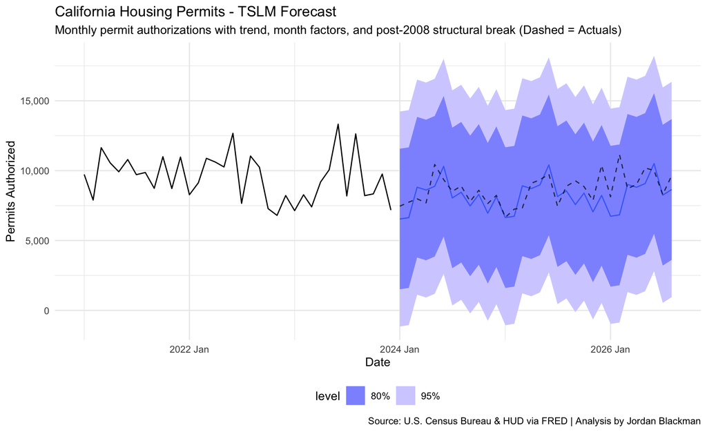

```r
p_tslm_fc <- ca_fc |>
  filter(.model == "tslm_regime") |>
  autoplot(tail(ca_trn, 36)) +
  geom_line(data = ca_tst, aes(x = Month, y = permits), color = "black", linetype = "dashed", alpha = 0.7) +
  scale_y_continuous(labels = scales::comma) +
  labs(
    title = "California Housing Permits - TSLM Forecast",
    subtitle = "Monthly permit authorizations with trend, month factors, and post-2008 structural break (Dashed = Actuals)",
    caption = "Source: U.S. Census Bureau & HUD via FRED | Analysis by Jordan Blackman",
    y = "Permits Authorized",
    x = "Date"
  ) +
  theme_minimal(base_size = 11) +
  theme(legend.position = "bottom")

p_tslm_fc
```

```r
# Save image for Canvas upload
ggsave("california_housing_permits_tslm_forecast.png", p_tslm_fc, width = 9, height = 5.5, dpi = 300)
```

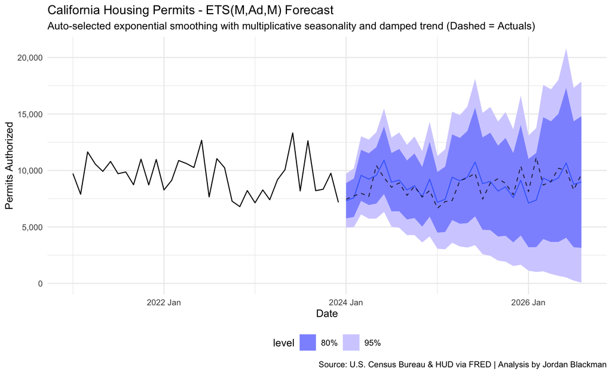

```r
p_ets_fc <- ca_fc |>
  filter(.model == "ets_auto") |>
  autoplot(tail(ca_trn, 36)) +
  geom_line(data = ca_tst, aes(x = Month, y = permits), color = "black", linetype = "dashed", alpha = 0.7) +
  scale_y_continuous(labels = scales::comma) +
  labs(
    title = "California Housing Permits - ETS(M,Ad,M) Forecast",
    subtitle = "Auto-selected exponential smoothing with multiplicative seasonality and damped trend (Dashed = Actuals)",
    caption = "Source: U.S. Census Bureau & HUD via FRED | Analysis by Jordan Blackman",
    y = "Permits Authorized",
    x = "Date"
  ) +
  theme_minimal(base_size = 11) +
  theme(legend.position = "bottom")

p_ets_fc
```

```r
# Save image for Canvas upload
ggsave("california_housing_permits_ets_forecast.png", p_ets_fc, width = 9, height = 5.5, dpi = 300)
```

## 8.3 Extended Multi-Year Historical Context (Customizable Training Window)

To view the forecast within a broader macroeconomic context, this plot displays an extended training history. You can adjust the number of preceding training years and select the model (`ets_auto` or `tslm_regime`) using the variables below. Both the **Forecast Mean** and **Actual Future Values** lines are explicitly labeled in the legend and annotated directly on the plot.

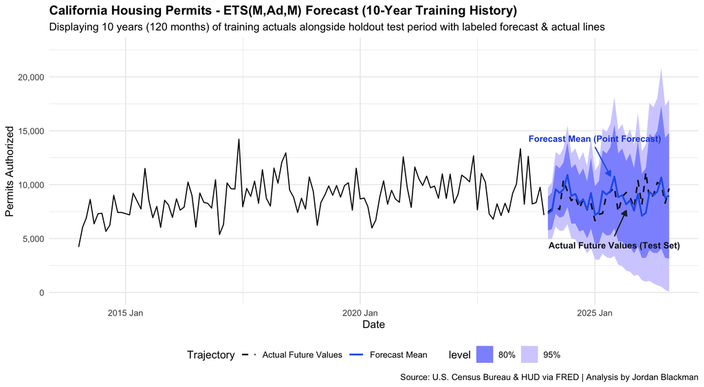

```r
# ==============================================================================
# USER-CONTROLLED PARAMETERS:
# history_years : Number of years of training history (e.g., 5, 7, 10, 15, 20)
# selected_model: Model to display ("ets_auto", "tslm_regime", "tslm_basic")
# ==============================================================================
history_years  <- 10
selected_model <- "ets_auto"

# Calculate corresponding number of monthly observations
history_months <- history_years * 12

# Model label for titles
model_label <- if (selected_model == "ets_auto") "ETS(M,Ad,M)" else "TSLM"

# Extract selected forecast series
fc_selected <- ca_fc |> filter(.model == selected_model)

# Plot Forecast with extended historical training actuals and explicit line labels
p_extended_fc <- fc_selected |>
  autoplot(tail(ca_trn, history_months), level = c(80, 95)) +
  # Actual future line with aesthetic mapping for legend
  geom_line(data = ca_tst, aes(x = Month, y = permits, color = "Actual Future Values", linetype = "Actual Future Values"), linewidth = 0.75) +
  # Forecast mean line with aesthetic mapping for legend
  geom_line(data = fc_selected, aes(x = Month, y = .mean, color = "Forecast Mean", linetype = "Forecast Mean"), linewidth = 0.85) +
  # Direct arrow & label pointing to Forecast Mean
  annotate("segment", x = yearmonth("2025 Jan"), xend = yearmonth("2025 May"),
           y = 13500, yend = 10800,
           arrow = arrow(length = unit(0.2, "cm"), type = "closed"), color = "#2563eb", linewidth = 0.6) +
  annotate("text", x = yearmonth("2025 Jan"), y = 14300,
           label = "Forecast Mean (Point Forecast)", color = "#1d4ed8", fontface = "bold", size = 3.2) +
  # Direct arrow & label pointing to Actual Future Values
  annotate("segment", x = yearmonth("2025 Jun"), xend = yearmonth("2025 Sep"),
           y = 5200, yend = 7600,
           arrow = arrow(length = unit(0.2, "cm"), type = "closed"), color = "#1f2937", linewidth = 0.6) +
  annotate("text", x = yearmonth("2025 Jun"), y = 4400,
           label = "Actual Future Values (Test Set)", color = "#111827", fontface = "bold", size = 3.2) +
  scale_y_continuous(labels = scales::comma, limits = c(0, 22500)) +
  scale_color_manual(
    name = "Trajectory",
    values = c("Actual Future Values" = "#111827", "Forecast Mean" = "#2563eb")
  ) +
  scale_linetype_manual(
    name = "Trajectory",
    values = c("Actual Future Values" = "dashed", "Forecast Mean" = "solid")
  ) +
  labs(
    title = paste0("California Housing Permits - ", model_label, " Forecast (", history_years, "-Year Training History)"),
    subtitle = paste0("Displaying ", history_years, " years (", history_months, " months) of training actuals alongside holdout test period with labeled forecast & actual lines"),
    caption = "Source: U.S. Census Bureau & HUD via FRED | Analysis by Jordan Blackman",
    y = "Permits Authorized",
    x = "Date"
  ) +
  theme_minimal(base_size = 11) +
  theme(
    legend.position = "bottom",
    legend.box = "horizontal",
    plot.title = element_text(face = "bold", size = 13)
  )

p_extended_fc
```

```r
# Save high-resolution graphic
output_filename <- paste0("california_housing_permits_", selected_model, "_", history_years, "yr_history.png")
ggsave(output_filename, p_extended_fc, width = 10, height = 5.5, dpi = 300)
message("Saved extended plot to: ", output_filename)
```

# 9. Canvas Discussion 2.1 Post Draft (Exact Exemplar Format)

**Data provided by the U.S. Census Bureau and the U.S. Department of Housing and Urban Development (via FRED).**  
The dataset reports monthly new private housing units authorized by building permits from 1988 through 2026. Building permits serve as an officially recognized leading economic indicator for residential construction starts. For this discussion, I’ve narrowed the analysis to California (`CABPPRIV`), partitioning the series to train on data through December 2023 and evaluate out-of-sample forecasts on 2024–2026.

I selected an automated Exponential Smoothing state space model (`ETS()`) to capture dynamic level adjustments, multiplicative annual seasonality, and a damped trend. I also attempted several Time Series Linear Models (`TSLM`) using trend, month factors, and structural breaks for comparison.

#### Model Parameters

```
Series: permits
Model: ETS(M,Ad,M)

Smoothing parameters:
  alpha = 0.3002 (level smoothing)
  beta  = 0.0187 (trend smoothing)
  gamma = 0.0002 (seasonal smoothing)
  phi   = 0.9414 (damping parameter)

Initial states:
  l[0] = 22,553.37
  b[0] = -27.76
  sigma^2: 0.0277
  AICc: 8948.59, BIC: 9020.17
  In-sample Pseudo R-squared: 0.8899
```

The auto-selected $\text{ETS}(M, A_d, M)$ model specifies multiplicative errors ($M$), an additive damped trend ($A_d$), and multiplicative seasonality ($M$). The moderate $\alpha = 0.30$ allows the baseline level to update dynamically with macroeconomic shifts, while the damping parameter $\phi = 0.941$ gradually flattens the trend slope into the future, preventing unrealistic downward projections. The multiplicative seasonal component effectively captures how spring permit surges expand proportionally during high-volume building cycles.

*(Attach Plot: `california_housing_permits_ets_auto_10yr_history.png` or `california_housing_permits_ets_forecast.png`)*

# 10. References

- Hyndman, R. J., & Athanasopoulos, G. (2021). *Forecasting: Principles and practice* (3rd ed.). OTexts: Melbourne, Australia. https://otexts.com/fpp3/
- U.S. Census Bureau, & U.S. Department of Housing and Urban Development. (2024). *New private housing units authorized by building permits for California (CABPPRIV)* [Data set]. Federal Reserve Bank of St. Louis (FRED). https://fred.stlouisfed.org/series/CABPPRIV